# Sunrise and Sunset Time of a Period

Hao-Ran Wu ( haoranwu @ zju.edu.cn )

2022-09-24

In this section we are concerned about how to calculate sunrise and sunset time of a period through the function `sunRS()`.

## Code Example(s)

```r
# Calculate 2016 Sunrise and Sunset Time of Kellogg Biological Station
# ********************************
#
# Calculate the sunrise and sunset time for year 2016 at Kellogg Biological Station
# (KBS), Michigan, USA. For more details about the algorithm used, see Campbell
# and Norman (2012).
#
# ********************************
# List of variables and units for this example
#
# 'path'        path of a CSV file, which conains one column (with table titles)
#                * column 1: observation date. Required format "dd/mm/yyyy"
# 'hours'       hours of the day
# 'lng'         longitute of the study site (decimal)
# 'lat'         latitude of the study site (decimal)
#
# Calculated variables in the program
# 'doy'         day of the year
# 'time_sr'     sunrise time (hour)
# 'time_ss'     sunset time (hour)
#
# ********************************
# Step 1: import package
require(bproce)

# Step 2: choose parameters
path  <- "./data/1-1B Switchgrass Time Series.csv"
lng   <- -85.446758
lat   <- 42.476708

# Step 3: read data
dat   <- read.csv(path)              # read the CSV file
                                     #  * column 1 ($date): observation date
                                     #  * column 2 ($t_max): not used
                                     #  * column 3 ($t_min): not used
day   <- as.numeric(lapply(strsplit(dat$date,"/"),function(xx) xx[1]))
                                     # extract day numbers from characters
month <- as.numeric(lapply(strsplit(dat$date,"/"),function(xx) xx[2]))
                                     # extract month numbers from characters
year  <- as.numeric(lapply(strsplit(dat$date,"/"),function(xx) xx[3]))
                                     # extract year numbers from characters

# Step 4: run the model
doys <- DOY(year, month, day)        # calculate day of the year (DOY)

time_sr <- as.numeric(lapply(lapply(doys, sunRS, lng, lat), function(xx) xx[1]))
                                     # calculate sunrise time
time_ss <- as.numeric(lapply(lapply(doys, sunRS, lng, lat), function(xx) xx[2]))
                                     # calculate sunset time
res <- data.frame(
  date = dat$date, time_sr, time_ss
)                             # calculated result
                              #  * column 1  ($date): observation date
                              #  * column 2  ($time_sr): sunrise time
                              #  * column 3  ($time_ss): sunset time

# Step 5: show and visualize results
print(res, digits = 3)        # present the output

plot(
  doys, time_sr, col=2, ylim=range(c(time_sr, time_ss)), type="l",
  xlab = "Day of the year", ylab = "Temperature",
  main = "2016 Sunrise and Sunset Time of Kellogg Biological Station"
)                             # plot dew point temperature versus time
lines(doys, time_ss, col=3, type="l")
                              # plot wet-bulb temperature versus time
legend("right", pch=c(15, 15), col=c(2, 3), bty="n",
       legend=c("Sunrise Time", "Sunset Time")) # add legends
```

## Explanation

**Step1:** Load the package `bproce` through the `require()` function.

```r
require(bproce)
```

**Step2:** Choose model parameters.

```r
path  <- "./data/1-1B Switchgrass Time Series.csv"
lng   <- -85.446758
lat   <- 42.476708
```

**Step3:** Read data. Read the CSV file in table format and creates a data frame through the function `read.csv()`. Note that only the first column is used in this example.

```r
dat <- read.csv(path)
head(dat)  #print first parts of the data
```

```
        date   t_max    t_min
1 01/01/2016 -2.1622  -4.1469
2 02/01/2016  3.1132  -2.1903
3 03/01/2016  1.8934  -2.8907
4 04/01/2016 -1.4289 -11.6573
5 05/01/2016  0.0201 -13.3976
6 06/01/2016  5.1338  -8.5460
```

Then the day, month, and year are extracted from date list through the function `strsplit()`.

```r
day   <- as.numeric(lapply(strsplit(dat$date,"/"),function(xx) xx[1]))
                                     # extract day numbers from characters
month <- as.numeric(lapply(strsplit(dat$date,"/"),function(xx) xx[2]))
                                     # extract month numbers from characters
year  <- as.numeric(lapply(strsplit(dat$date,"/"),function(xx) xx[3]))
                                     # extract year numbers from characters

cat(
  "Dates:",head(dat$date),"...\n",
  "************Extract day, month, and year numbers************\n",
  "Days:",head(day),"...\n",
  "Months:",head(month),"...\n",
  "Years:",head(year),"...\n"
)
```

```
Dates: 01/01/2016 02/01/2016 03/01/2016 04/01/2016 05/01/2016 06/01/2016 ...
 ************Extract day, month, and year numbers************
 Days: 1 2 3 4 5 6 ...
 Months: 1 1 1 1 1 1 ...
 Years: 2016 2016 2016 2016 2016 2016 ...
```

**Step4:** Run the model. The first step is to calculate day of the year (DOY) using the following equation:

$$\text{DOY}=\left[ \frac{275\text{month}}{9}
\right]-\left[\frac{\text{month}+9}{12}\right]·
\left(\left[ \frac{\text{year}-4\text[\text{year}/4]+2}{3}
\right]+1\right)+\text{day}-30,\quad(1)$$

```r
doys <- DOY(year, month, day)          # calculate day of the year (DOY)

cat(                                   # present the output
  "Dates:", head(dat$date),"...\n",
  "DOYs:", head(doys),"...\n"
)
```

```
Dates: 01/01/2016 02/01/2016 03/01/2016 04/01/2016 05/01/2016 06/01/2016 ...
 DOYs: 1 2 3 4 5 6 ...
```

Sunrise time (Time<sub>sr</sub>, hour) is calculated as:

$$\text{Time}_{sr}=12-\frac{1}{15}\cos^{-1}\left(\frac{-\sin\Phi\sin\delta}{\cos\Phi\cos\delta}
\right)-\frac{t}{60},\quad(2)$$

where $\Phi$ is latitude (decimal), $\delta$ is solar declination (decimal), $t$ is local time (hour) which can be estimated from longitude. Sunset time (Time<sub>ss</sub>, hour) can be estimated by:

$$\text{Time}_{ss}=12+\frac1{15}\cos^{-1}\left(\frac{-\sin\Phi\sin\delta}{\cos\Phi\cos\delta}\right)-\frac
t{60},\quad(3)$$

Solar declination ($\delta$) is calculated as:

$$\delta = -23.25·\cos\left[\frac{360}{365}(\text{DOY}+10)
\right],\quad(4)$$

Calculation of Time<sub>sr</sub> and Time<sub>ss</sub> via equation (2–4) can be done through the function `sunRS`:

```r
time_sr <- as.numeric(lapply(lapply(doys, sunRS, lng, lat), function(xx) xx[1]))
                                      # calculate sunrise time
time_ss <- as.numeric(lapply(lapply(doys, sunRS, lng, lat), function(xx) xx[2]))
                                      # calculate sunset time

cat(
  paste0("Longitude = ",lng, ", Latitude = ",lat,"\n"),
  "Date:", head(dat$date),"...\n",
  "Sunrise Time:", round(head(time_sr),3),"... (hour)\n",
  "Sunset Time:", round(head(time_ss),3),"... (hour)\n"
)                                     # present the output
```

```
Longitude = -85.446758, Latitude = 42.476708
 Date: 01/01/2016 02/01/2016 03/01/2016 04/01/2016 05/01/2016 06/01/2016 ...
 Sunrise Time: 7.496 7.498 7.498 7.498 7.497 7.496 ... (hour)
 Sunset Time: 16.63 16.645 16.66 16.675 16.691 16.708 ... (hour)
```

Now we can combine the calculated results by columns and view them.

```r
res <- data.frame(
  date = dat$date, time_sr, time_ss
)                             # calculated result
                              #  * column 1  ($date): observation date
                              #  * column 2  ($time_sr): sunrise time
                              #  * column 3  ($time_ss): sunset time
print(head(res), digits = 3)
```

```
        date time_sr time_ss
1 01/01/2016     7.5    16.6
2 02/01/2016     7.5    16.6
3 03/01/2016     7.5    16.7
4 04/01/2016     7.5    16.7
5 05/01/2016     7.5    16.7
6 06/01/2016     7.5    16.7
```

**Step5:** Save and visualize results. Use the `write.csv()` function to send outputs to a CSV file.

```r
write.csv(res,
          "./data/1-4B Switchgrass Sunrise and Sunset Time Output.csv",
          row.names = FALSE)
```

Create a line plot of calculated variables against time through the function `plot()`:

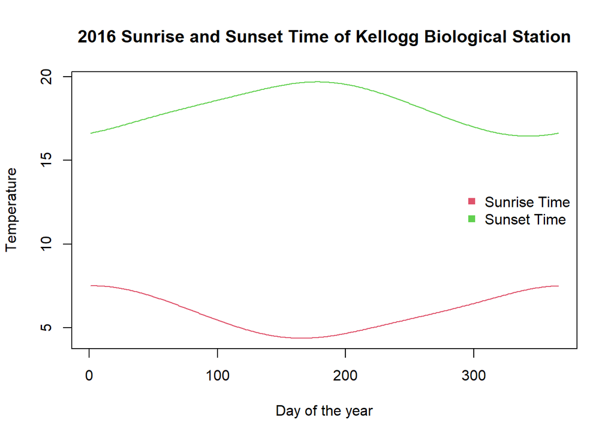

```r
plot(
  doys, time_sr, col=2, ylim=range(c(time_sr, time_ss)), type="l",
  xlab = "Day of the year", ylab = "Temperature",
  main = "2016 Sunrise and Sunset Time of Kellogg Biological Station"
)                             # plot dew point temperature versus time
lines(doys, time_ss, col=3, type="l")
                              # plot wet-bulb temperature versus time
legend("right", pch=c(15, 15), col=c(2, 3), bty="n",
       legend=c("Sunrise Time", "Sunset Time")) # add legends
```

## Reference

Campbell, G. S., and Norman, J. (2012). An Introduction to Environmental Biophysics. Springer Science & Business Media. 286pp.